# Risk Factor Analysis

## Outcome Variable

**Outcome Variable:** wast_rec90d

## Predictor Variables

**Intervention Variable:** predexfd6

**Adjustment Set:**

- arm
- sex
- W_mage
- meducyrs
- feducyrs
- hhwealth_quart
- hfoodsec
- W_mhtcm
- vagbrth
- W_gagebrth
- W_birthwt
- W_birthlen
- W_nrooms
- W_nchldlt5
- month
- brthmon
- W_parity
- impfloor
- impsan
- safeh20
- delta_W_mage
- delta_meducyrs
- delta_feducyrs
- delta_hhwealth_quart
- delta_hfoodsec
- delta_W_mhtcm
- delta_vagbrth
- delta_W_gagebrth
- delta_W_birthwt
- delta_W_birthlen
- delta_W_nrooms
- delta_W_nchldlt5
- delta_month
- delta_brthmon
- delta_W_parity
- delta_impfloor
- delta_impsan
- delta_safeh20

## Stratifying Variables

The analysis was stratified on these variable(s):

- agecat
- studyid
- country

## Data Summary

| agecat | studyid | country | predexfd6 | wast_rec90d | n_cell | n |
| --- | --- | --- | --- | --- | --- | --- |
| 0-24 months | ki0047075b-MAL-ED | BANGLADESH | 0 | 0 | 18 | 121 |
| 0-24 months | ki0047075b-MAL-ED | BANGLADESH | 0 | 1 | 35 | 121 |
| 0-24 months | ki0047075b-MAL-ED | BANGLADESH | 1 | 0 | 26 | 121 |
| 0-24 months | ki0047075b-MAL-ED | BANGLADESH | 1 | 1 | 42 | 121 |
| 0-24 months | ki0047075b-MAL-ED | BRAZIL | 0 | 0 | 5 | 23 |
| 0-24 months | ki0047075b-MAL-ED | BRAZIL | 0 | 1 | 17 | 23 |
| 0-24 months | ki0047075b-MAL-ED | BRAZIL | 1 | 0 | 1 | 23 |
| 0-24 months | ki0047075b-MAL-ED | BRAZIL | 1 | 1 | 0 | 23 |
| 0-24 months | ki0047075b-MAL-ED | INDIA | 0 | 0 | 64 | 170 |
| 0-24 months | ki0047075b-MAL-ED | INDIA | 0 | 1 | 97 | 170 |
| 0-24 months | ki0047075b-MAL-ED | INDIA | 1 | 0 | 2 | 170 |
| 0-24 months | ki0047075b-MAL-ED | INDIA | 1 | 1 | 7 | 170 |
| 0-24 months | ki0047075b-MAL-ED | NEPAL | 0 | 0 | 17 | 90 |
| 0-24 months | ki0047075b-MAL-ED | NEPAL | 0 | 1 | 68 | 90 |
| 0-24 months | ki0047075b-MAL-ED | NEPAL | 1 | 0 | 1 | 90 |
| 0-24 months | ki0047075b-MAL-ED | NEPAL | 1 | 1 | 4 | 90 |
| 0-24 months | ki0047075b-MAL-ED | PERU | 0 | 0 | 4 | 29 |
| 0-24 months | ki0047075b-MAL-ED | PERU | 0 | 1 | 19 | 29 |
| 0-24 months | ki0047075b-MAL-ED | PERU | 1 | 0 | 1 | 29 |
| 0-24 months | ki0047075b-MAL-ED | PERU | 1 | 1 | 5 | 29 |
| 0-24 months | ki0047075b-MAL-ED | SOUTH AFRICA | 0 | 0 | 12 | 77 |
| 0-24 months | ki0047075b-MAL-ED | SOUTH AFRICA | 0 | 1 | 65 | 77 |
| 0-24 months | ki0047075b-MAL-ED | SOUTH AFRICA | 1 | 0 | 0 | 77 |
| 0-24 months | ki0047075b-MAL-ED | SOUTH AFRICA | 1 | 1 | 0 | 77 |
| 0-24 months | ki0047075b-MAL-ED | TANZANIA, UNITED REPUBLIC OF | 0 | 0 | 8 | 45 |
| 0-24 months | ki0047075b-MAL-ED | TANZANIA, UNITED REPUBLIC OF | 0 | 1 | 37 | 45 |
| 0-24 months | ki0047075b-MAL-ED | TANZANIA, UNITED REPUBLIC OF | 1 | 0 | 0 | 45 |
| 0-24 months | ki0047075b-MAL-ED | TANZANIA, UNITED REPUBLIC OF | 1 | 1 | 0 | 45 |
| 0-24 months | ki1000108-CMC-V-BCS-2002 | INDIA | 0 | 0 | 0 | 16 |
| 0-24 months | ki1000108-CMC-V-BCS-2002 | INDIA | 0 | 1 | 0 | 16 |

[output cut: 186 more lines]

The following strata were considered:

- agecat: 0-24 months, studyid: ki0047075b-MAL-ED, country: BANGLADESH
- agecat: 0-24 months, studyid: ki0047075b-MAL-ED, country: BRAZIL
- agecat: 0-24 months, studyid: ki0047075b-MAL-ED, country: INDIA
- agecat: 0-24 months, studyid: ki0047075b-MAL-ED, country: NEPAL
- agecat: 0-24 months, studyid: ki0047075b-MAL-ED, country: PERU
- agecat: 0-24 months, studyid: ki0047075b-MAL-ED, country: SOUTH AFRICA
- agecat: 0-24 months, studyid: ki0047075b-MAL-ED, country: TANZANIA, UNITED REPUBLIC OF
- agecat: 0-24 months, studyid: ki1000108-CMC-V-BCS-2002, country: INDIA
- agecat: 0-24 months, studyid: ki1000108-IRC, country: INDIA
- agecat: 0-24 months, studyid: ki1000109-EE, country: PAKISTAN
- agecat: 0-24 months, studyid: ki1000304b-SAS-CompFeed, country: INDIA
- agecat: 0-24 months, studyid: ki1000304b-SAS-FoodSuppl, country: INDIA
- agecat: 0-24 months, studyid: ki1017093b-PROVIDE, country: BANGLADESH
- agecat: 0-24 months, studyid: ki1101329-Keneba, country: GAMBIA
- agecat: 0-24 months, studyid: ki1113344-GMS-Nepal, country: NEPAL
- agecat: 0-24 months, studyid: ki1148112-LCNI-5, country: MALAWI
- agecat: 0-24 months, studyid: kiGH5241-JiVitA-3, country: BANGLADESH
- agecat: 0-24 months, studyid: kiGH5241-JiVitA-4, country: BANGLADESH
- agecat: 0-6 months, studyid: ki0047075b-MAL-ED, country: BANGLADESH
- agecat: 0-6 months, studyid: ki0047075b-MAL-ED, country: BRAZIL
- agecat: 0-6 months, studyid: ki0047075b-MAL-ED, country: INDIA
- agecat: 0-6 months, studyid: ki0047075b-MAL-ED, country: NEPAL
- agecat: 0-6 months, studyid: ki0047075b-MAL-ED, country: PERU
- agecat: 0-6 months, studyid: ki0047075b-MAL-ED, country: SOUTH AFRICA
- agecat: 0-6 months, studyid: ki0047075b-MAL-ED, country: TANZANIA, UNITED REPUBLIC OF
- agecat: 0-6 months, studyid: ki1000108-CMC-V-BCS-2002, country: INDIA
- agecat: 0-6 months, studyid: ki1000108-IRC, country: INDIA
- agecat: 0-6 months, studyid: ki1000109-EE, country: PAKISTAN
- agecat: 0-6 months, studyid: ki1000304b-SAS-CompFeed, country: INDIA
- agecat: 0-6 months, studyid: ki1000304b-SAS-FoodSuppl, country: INDIA
- agecat: 0-6 months, studyid: ki1017093b-PROVIDE, country: BANGLADESH
- agecat: 0-6 months, studyid: ki1101329-Keneba, country: GAMBIA
- agecat: 0-6 months, studyid: ki1113344-GMS-Nepal, country: NEPAL
- agecat: 0-6 months, studyid: ki1148112-LCNI-5, country: MALAWI
- agecat: 0-6 months, studyid: kiGH5241-JiVitA-3, country: BANGLADESH
- agecat: 0-6 months, studyid: kiGH5241-JiVitA-4, country: BANGLADESH
- agecat: 6-24 months, studyid: ki0047075b-MAL-ED, country: BANGLADESH
- agecat: 6-24 months, studyid: ki0047075b-MAL-ED, country: BRAZIL
- agecat: 6-24 months, studyid: ki0047075b-MAL-ED, country: INDIA
- agecat: 6-24 months, studyid: ki0047075b-MAL-ED, country: NEPAL
- agecat: 6-24 months, studyid: ki0047075b-MAL-ED, country: PERU
- agecat: 6-24 months, studyid: ki0047075b-MAL-ED, country: SOUTH AFRICA
- agecat: 6-24 months, studyid: ki0047075b-MAL-ED, country: TANZANIA, UNITED REPUBLIC OF
- agecat: 6-24 months, studyid: ki1000108-CMC-V-BCS-2002, country: INDIA
- agecat: 6-24 months, studyid: ki1000108-IRC, country: INDIA
- agecat: 6-24 months, studyid: ki1000109-EE, country: PAKISTAN
- agecat: 6-24 months, studyid: ki1000304b-SAS-CompFeed, country: INDIA
- agecat: 6-24 months, studyid: ki1000304b-SAS-FoodSuppl, country: INDIA
- agecat: 6-24 months, studyid: ki1017093b-PROVIDE, country: BANGLADESH
- agecat: 6-24 months, studyid: ki1101329-Keneba, country: GAMBIA
- agecat: 6-24 months, studyid: ki1113344-GMS-Nepal, country: NEPAL
- agecat: 6-24 months, studyid: ki1148112-LCNI-5, country: MALAWI
- agecat: 6-24 months, studyid: kiGH5241-JiVitA-3, country: BANGLADESH
- agecat: 6-24 months, studyid: kiGH5241-JiVitA-4, country: BANGLADESH

### Dropped Strata

Some strata were dropped due to rare outcomes:

- agecat: 0-24 months, studyid: ki0047075b-MAL-ED, country: BRAZIL
- agecat: 0-24 months, studyid: ki0047075b-MAL-ED, country: INDIA
- agecat: 0-24 months, studyid: ki0047075b-MAL-ED, country: NEPAL
- agecat: 0-24 months, studyid: ki0047075b-MAL-ED, country: PERU
- agecat: 0-24 months, studyid: ki0047075b-MAL-ED, country: SOUTH AFRICA
- agecat: 0-24 months, studyid: ki0047075b-MAL-ED, country: TANZANIA, UNITED REPUBLIC OF
- agecat: 0-24 months, studyid: ki1000108-CMC-V-BCS-2002, country: INDIA
- agecat: 0-24 months, studyid: ki1000108-IRC, country: INDIA
- agecat: 0-24 months, studyid: ki1000304b-SAS-FoodSuppl, country: INDIA
- agecat: 0-24 months, studyid: ki1148112-LCNI-5, country: MALAWI
- agecat: 0-6 months, studyid: ki0047075b-MAL-ED, country: BRAZIL
- agecat: 0-6 months, studyid: ki0047075b-MAL-ED, country: INDIA
- agecat: 0-6 months, studyid: ki0047075b-MAL-ED, country: NEPAL
- agecat: 0-6 months, studyid: ki0047075b-MAL-ED, country: PERU
- agecat: 0-6 months, studyid: ki0047075b-MAL-ED, country: SOUTH AFRICA
- agecat: 0-6 months, studyid: ki0047075b-MAL-ED, country: TANZANIA, UNITED REPUBLIC OF
- agecat: 0-6 months, studyid: ki1000108-CMC-V-BCS-2002, country: INDIA
- agecat: 0-6 months, studyid: ki1000108-IRC, country: INDIA
- agecat: 0-6 months, studyid: ki1000304b-SAS-CompFeed, country: INDIA
- agecat: 0-6 months, studyid: ki1000304b-SAS-FoodSuppl, country: INDIA
- agecat: 0-6 months, studyid: ki1148112-LCNI-5, country: MALAWI
- agecat: 6-24 months, studyid: ki0047075b-MAL-ED, country: BRAZIL
- agecat: 6-24 months, studyid: ki0047075b-MAL-ED, country: INDIA
- agecat: 6-24 months, studyid: ki0047075b-MAL-ED, country: NEPAL
- agecat: 6-24 months, studyid: ki0047075b-MAL-ED, country: PERU
- agecat: 6-24 months, studyid: ki0047075b-MAL-ED, country: SOUTH AFRICA
- agecat: 6-24 months, studyid: ki0047075b-MAL-ED, country: TANZANIA, UNITED REPUBLIC OF
- agecat: 6-24 months, studyid: ki1000108-CMC-V-BCS-2002, country: INDIA
- agecat: 6-24 months, studyid: ki1000108-IRC, country: INDIA
- agecat: 6-24 months, studyid: ki1000304b-SAS-CompFeed, country: INDIA
- agecat: 6-24 months, studyid: ki1000304b-SAS-FoodSuppl, country: INDIA
- agecat: 6-24 months, studyid: ki1148112-LCNI-5, country: MALAWI
- agecat: 6-24 months, studyid: kiGH5241-JiVitA-3, country: BANGLADESH

## Methods Detail

We’re interested in the causal parameters $E[Y_a]$ for all values of $a \in \mathcal{A}$. These parameters represent the mean outcome if, possibly contrary to fact, we intervened to set all units to have $A=a$. Under the randomization and positivity assumptions, these are identified by the statistical parameters $\psi_a=E_W[E_{Y|A,W}(Y|A=a,W)]$. In addition, we’re interested in the mean of $Y$, $E[Y]$ under no intervention (the observed mean). We will estimate these parameters by using SuperLearner to fit the relevant likelihood factors – $E_{Y|A,W}(Y|A=a,W)$ and $p(A=a|W)$, and then updating our likelihood fit using a joint TMLE.

For unadjusted analyses ($W=\{\}$), initial likelihoods were estimated using Lrnr_glm to estimate the simple $E(Y|A)$ and Lrnr_mean to estimate $p(A)$. For adjusted analyses, a small library containing Lrnr_glmnet, Lrnr_xgboost, and Lrnr_mean was used.

Having estimated these parameters, we will then use the delta method to estimate relative risks and attributable risks relative to a prespecified baseline level of $A$.

# Results Detail

## Results Plots

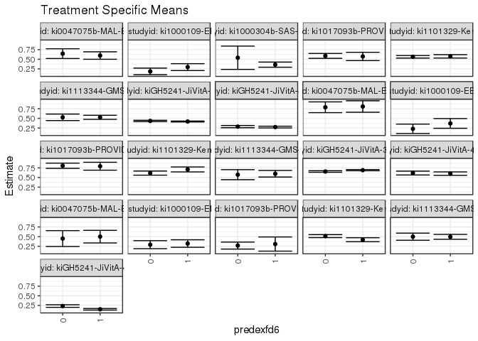

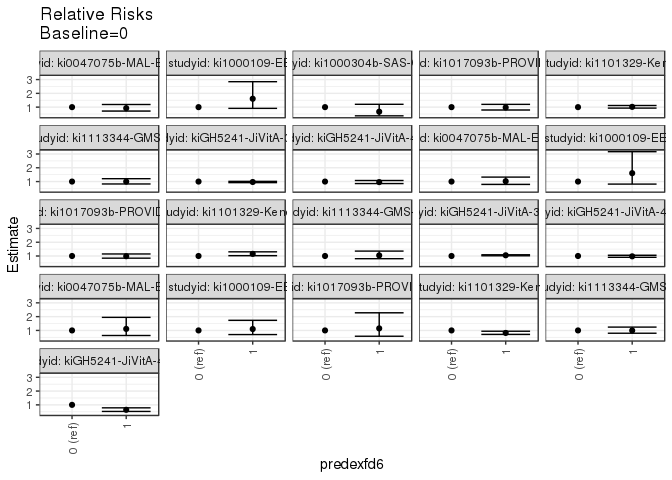

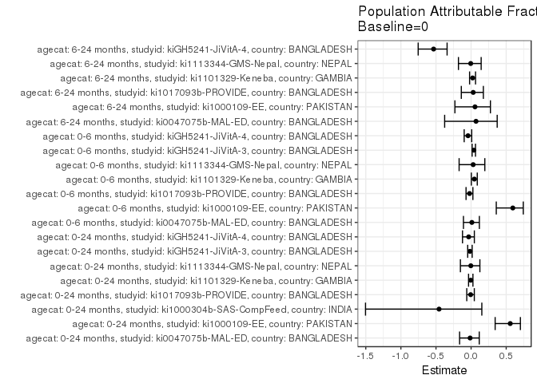

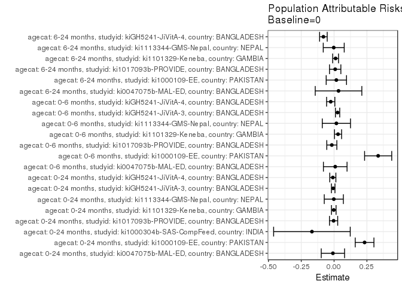

## Results Table

### Parameter: TSM

| agecat | studyid | country | intervention_level | baseline_level | estimate | ci_lower | ci_upper |
| --- | --- | --- | --- | --- | --- | --- | --- |
| 0-24 months | ki0047075b-MAL-ED | BANGLADESH | 0 | NA | 0.6453628 | 0.5188925 | 0.7718331 |
| 0-24 months | ki0047075b-MAL-ED | BANGLADESH | 1 | NA | 0.5960133 | 0.4993253 | 0.6927013 |
| 0-24 months | ki1000109-EE | PAKISTAN | 0 | NA | 0.1841532 | 0.0981056 | 0.2702009 |
| 0-24 months | ki1000109-EE | PAKISTAN | 1 | NA | 0.2962676 | 0.2070710 | 0.3854642 |
| 0-24 months | ki1000304b-SAS-CompFeed | INDIA | 0 | NA | 0.5384615 | 0.2364546 | 0.8404685 |
| 0-24 months | ki1000304b-SAS-CompFeed | INDIA | 1 | NA | 0.3600000 | 0.2937351 | 0.4262649 |
| 0-24 months | ki1017093b-PROVIDE | BANGLADESH | 0 | NA | 0.5868215 | 0.5231413 | 0.6505016 |
| 0-24 months | ki1017093b-PROVIDE | BANGLADESH | 1 | NA | 0.5723269 | 0.4650084 | 0.6796455 |
| 0-24 months | ki1101329-Keneba | GAMBIA | 0 | NA | 0.5635395 | 0.5309038 | 0.5961753 |
| 0-24 months | ki1101329-Keneba | GAMBIA | 1 | NA | 0.5751261 | 0.5310456 | 0.6192065 |
| 0-24 months | ki1113344-GMS-Nepal | NEPAL | 0 | NA | 0.5280923 | 0.4438388 | 0.6123458 |
| 0-24 months | ki1113344-GMS-Nepal | NEPAL | 1 | NA | 0.5273536 | 0.4738402 | 0.5808671 |
| 0-24 months | kiGH5241-JiVitA-3 | BANGLADESH | 0 | NA | 0.4329930 | 0.4159805 | 0.4500055 |
| 0-24 months | kiGH5241-JiVitA-3 | BANGLADESH | 1 | NA | 0.4190516 | 0.4068222 | 0.4312809 |
| 0-24 months | kiGH5241-JiVitA-4 | BANGLADESH | 0 | NA | 0.2862334 | 0.2573092 | 0.3151576 |
| 0-24 months | kiGH5241-JiVitA-4 | BANGLADESH | 1 | NA | 0.2746831 | 0.2519507 | 0.2974155 |
| 0-6 months | ki0047075b-MAL-ED | BANGLADESH | 0 | NA | 0.7878788 | 0.6482934 | 0.9274642 |
| 0-6 months | ki0047075b-MAL-ED | BANGLADESH | 1 | NA | 0.8076923 | 0.6590088 | 0.9563759 |
| 0-6 months | ki1000109-EE | PAKISTAN | 0 | NA | 0.2291855 | 0.1069983 | 0.3513727 |
| 0-6 months | ki1000109-EE | PAKISTAN | 1 | NA | 0.3687247 | 0.2427373 | 0.4947121 |
| 0-6 months | ki1017093b-PROVIDE | BANGLADESH | 0 | NA | 0.8053483 | 0.7382646 | 0.8724321 |
| 0-6 months | ki1017093b-PROVIDE | BANGLADESH | 1 | NA | 0.7921743 | 0.6897525 | 0.8945961 |
| 0-6 months | ki1101329-Keneba | GAMBIA | 0 | NA | 0.6142279 | 0.5603944 | 0.6680614 |
| 0-6 months | ki1101329-Keneba | GAMBIA | 1 | NA | 0.7093604 | 0.6454672 | 0.7732536 |
| 0-6 months | ki1113344-GMS-Nepal | NEPAL | 0 | NA | 0.5731621 | 0.4434318 | 0.7028925 |
| 0-6 months | ki1113344-GMS-Nepal | NEPAL | 1 | NA | 0.5977188 | 0.5120360 | 0.6834016 |
| 0-6 months | kiGH5241-JiVitA-3 | BANGLADESH | 0 | NA | 0.6561828 | 0.6358575 | 0.6765080 |
| 0-6 months | kiGH5241-JiVitA-3 | BANGLADESH | 1 | NA | 0.6901386 | 0.6754077 | 0.7048695 |
| 0-6 months | kiGH5241-JiVitA-4 | BANGLADESH | 0 | NA | 0.6156387 | 0.5655889 | 0.6656886 |
| 0-6 months | kiGH5241-JiVitA-4 | BANGLADESH | 1 | NA | 0.6009184 | 0.5560141 | 0.6458226 |
| 6-24 months | ki0047075b-MAL-ED | BANGLADESH | 0 | NA | 0.4500000 | 0.2444054 | 0.6555946 |
| 6-24 months | ki0047075b-MAL-ED | BANGLADESH | 1 | NA | 0.5000000 | 0.3367001 | 0.6632999 |
| 6-24 months | ki1000109-EE | PAKISTAN | 0 | NA | 0.2915036 | 0.1879103 | 0.3950969 |
| 6-24 months | ki1000109-EE | PAKISTAN | 1 | NA | 0.3207872 | 0.2231752 | 0.4183992 |
| 6-24 months | ki1017093b-PROVIDE | BANGLADESH | 0 | NA | 0.2680412 | 0.1773699 | 0.3587126 |
| 6-24 months | ki1017093b-PROVIDE | BANGLADESH | 1 | NA | 0.3076923 | 0.1243207 | 0.4910639 |
| 6-24 months | ki1101329-Keneba | GAMBIA | 0 | NA | 0.5134156 | 0.4747304 | 0.5521008 |
| 6-24 months | ki1101329-Keneba | GAMBIA | 1 | NA | 0.4204178 | 0.3694000 | 0.4714355 |
| 6-24 months | ki1113344-GMS-Nepal | NEPAL | 0 | NA | 0.4985929 | 0.4064340 | 0.5907519 |
| 6-24 months | ki1113344-GMS-Nepal | NEPAL | 1 | NA | 0.4957159 | 0.4321622 | 0.5592695 |
| 6-24 months | kiGH5241-JiVitA-4 | BANGLADESH | 0 | NA | 0.2334799 | 0.1998435 | 0.2671163 |
| 6-24 months | kiGH5241-JiVitA-4 | BANGLADESH | 1 | NA | 0.1495852 | 0.1286937 | 0.1704767 |

### Parameter: E(Y)

| agecat | studyid | country | intervention_level | baseline_level | estimate | ci_lower | ci_upper |
| --- | --- | --- | --- | --- | --- | --- | --- |
| 0-24 months | ki0047075b-MAL-ED | BANGLADESH | NA | NA | 0.6363636 | 0.5494154 | 0.7233119 |
| 0-24 months | ki1000109-EE | PAKISTAN | NA | NA | 0.4163424 | 0.3511349 | 0.4815500 |
| 0-24 months | ki1000304b-SAS-CompFeed | INDIA | NA | NA | 0.3697479 | 0.3045176 | 0.4349782 |
| 0-24 months | ki1017093b-PROVIDE | BANGLADESH | NA | NA | 0.5830619 | 0.5262762 | 0.6398476 |
| 0-24 months | ki1101329-Keneba | GAMBIA | NA | NA | 0.5610860 | 0.5320121 | 0.5901599 |
| 0-24 months | ki1113344-GMS-Nepal | NEPAL | NA | NA | 0.5260223 | 0.4802445 | 0.5718001 |
| 0-24 months | kiGH5241-JiVitA-3 | BANGLADESH | NA | NA | 0.4262098 | 0.4150208 | 0.4373989 |
| 0-24 months | kiGH5241-JiVitA-4 | BANGLADESH | NA | NA | 0.2766885 | 0.2556490 | 0.2977279 |
| 0-6 months | ki0047075b-MAL-ED | BANGLADESH | NA | NA | 0.7966102 | 0.6946250 | 0.8985954 |
| 0-6 months | ki1000109-EE | PAKISTAN | NA | NA | 0.5648148 | 0.4692893 | 0.6603404 |
| 0-6 months | ki1017093b-PROVIDE | BANGLADESH | NA | NA | 0.7880435 | 0.7295878 | 0.8464992 |
| 0-6 months | ki1101329-Keneba | GAMBIA | NA | NA | 0.6442786 | 0.5973688 | 0.6911884 |
| 0-6 months | ki1113344-GMS-Nepal | NEPAL | NA | NA | 0.5906433 | 0.5164645 | 0.6648221 |
| 0-6 months | kiGH5241-JiVitA-3 | BANGLADESH | NA | NA | 0.6828279 | 0.6694976 | 0.6961581 |
| 0-6 months | kiGH5241-JiVitA-4 | BANGLADESH | NA | NA | 0.5900383 | 0.5478064 | 0.6322702 |
| 6-24 months | ki0047075b-MAL-ED | BANGLADESH | NA | NA | 0.4838710 | 0.3544124 | 0.6133295 |
| 6-24 months | ki1000109-EE | PAKISTAN | NA | NA | 0.3087248 | 0.2336906 | 0.3837591 |
| 6-24 months | ki1017093b-PROVIDE | BANGLADESH | NA | NA | 0.2764228 | 0.1950773 | 0.3577682 |
| 6-24 months | ki1101329-Keneba | GAMBIA | NA | NA | 0.5248918 | 0.4904236 | 0.5593599 |
| 6-24 months | ki1113344-GMS-Nepal | NEPAL | NA | NA | 0.4959128 | 0.4403572 | 0.5514684 |
| 6-24 months | kiGH5241-JiVitA-4 | BANGLADESH | NA | NA | 0.1522070 | 0.1331665 | 0.1712475 |

### Parameter: RR

| agecat | studyid | country | intervention_level | baseline_level | estimate | ci_lower | ci_upper |
| --- | --- | --- | --- | --- | --- | --- | --- |
| 0-24 months | ki0047075b-MAL-ED | BANGLADESH | 0 | 0 | 1.0000000 | 1.0000000 | 1.0000000 |
| 0-24 months | ki0047075b-MAL-ED | BANGLADESH | 1 | 0 | 0.9235322 | 0.7153369 | 1.1923218 |
| 0-24 months | ki1000109-EE | PAKISTAN | 0 | 0 | 1.0000000 | 1.0000000 | 1.0000000 |
| 0-24 months | ki1000109-EE | PAKISTAN | 1 | 0 | 1.6088100 | 0.9094177 | 2.8460735 |
| 0-24 months | ki1000304b-SAS-CompFeed | INDIA | 0 | 0 | 1.0000000 | 1.0000000 | 1.0000000 |
| 0-24 months | ki1000304b-SAS-CompFeed | INDIA | 1 | 0 | 0.6685714 | 0.3704954 | 1.2064597 |
| 0-24 months | ki1017093b-PROVIDE | BANGLADESH | 0 | 0 | 1.0000000 | 1.0000000 | 1.0000000 |
| 0-24 months | ki1017093b-PROVIDE | BANGLADESH | 1 | 0 | 0.9752999 | 0.7918065 | 1.2013161 |
| 0-24 months | ki1101329-Keneba | GAMBIA | 0 | 0 | 1.0000000 | 1.0000000 | 1.0000000 |
| 0-24 months | ki1101329-Keneba | GAMBIA | 1 | 0 | 1.0205603 | 0.9316751 | 1.1179254 |
| 0-24 months | ki1113344-GMS-Nepal | NEPAL | 0 | 0 | 1.0000000 | 1.0000000 | 1.0000000 |
| 0-24 months | ki1113344-GMS-Nepal | NEPAL | 1 | 0 | 0.9986013 | 0.8264926 | 1.2065498 |
| 0-24 months | kiGH5241-JiVitA-3 | BANGLADESH | 0 | 0 | 1.0000000 | 1.0000000 | 1.0000000 |
| 0-24 months | kiGH5241-JiVitA-3 | BANGLADESH | 1 | 0 | 0.9678022 | 0.9258621 | 1.0116421 |
| 0-24 months | kiGH5241-JiVitA-4 | BANGLADESH | 0 | 0 | 1.0000000 | 1.0000000 | 1.0000000 |
| 0-24 months | kiGH5241-JiVitA-4 | BANGLADESH | 1 | 0 | 0.9596471 | 0.8553799 | 1.0766241 |
| 0-6 months | ki0047075b-MAL-ED | BANGLADESH | 0 | 0 | 1.0000000 | 1.0000000 | 1.0000000 |
| 0-6 months | ki0047075b-MAL-ED | BANGLADESH | 1 | 0 | 1.0251479 | 0.7940050 | 1.3235789 |
| 0-6 months | ki1000109-EE | PAKISTAN | 0 | 0 | 1.0000000 | 1.0000000 | 1.0000000 |
| 0-6 months | ki1000109-EE | PAKISTAN | 1 | 0 | 1.6088482 | 0.8168430 | 3.1687764 |
| 0-6 months | ki1017093b-PROVIDE | BANGLADESH | 0 | 0 | 1.0000000 | 1.0000000 | 1.0000000 |
| 0-6 months | ki1017093b-PROVIDE | BANGLADESH | 1 | 0 | 0.9836418 | 0.8435320 | 1.1470238 |
| 0-6 months | ki1101329-Keneba | GAMBIA | 0 | 0 | 1.0000000 | 1.0000000 | 1.0000000 |
| 0-6 months | ki1101329-Keneba | GAMBIA | 1 | 0 | 1.1548814 | 1.0236407 | 1.3029485 |
| 0-6 months | ki1113344-GMS-Nepal | NEPAL | 0 | 0 | 1.0000000 | 1.0000000 | 1.0000000 |
| 0-6 months | ki1113344-GMS-Nepal | NEPAL | 1 | 0 | 1.0428442 | 0.8029296 | 1.3544451 |
| 0-6 months | kiGH5241-JiVitA-3 | BANGLADESH | 0 | 0 | 1.0000000 | 1.0000000 | 1.0000000 |
| 0-6 months | kiGH5241-JiVitA-3 | BANGLADESH | 1 | 0 | 1.0517476 | 1.0153795 | 1.0894182 |
| 0-6 months | kiGH5241-JiVitA-4 | BANGLADESH | 0 | 0 | 1.0000000 | 1.0000000 | 1.0000000 |
| 0-6 months | kiGH5241-JiVitA-4 | BANGLADESH | 1 | 0 | 0.9760893 | 0.9055201 | 1.0521580 |
| 6-24 months | ki0047075b-MAL-ED | BANGLADESH | 0 | 0 | 1.0000000 | 1.0000000 | 1.0000000 |
| 6-24 months | ki0047075b-MAL-ED | BANGLADESH | 1 | 0 | 1.1111111 | 0.6335362 | 1.9486934 |
| 6-24 months | ki1000109-EE | PAKISTAN | 0 | 0 | 1.0000000 | 1.0000000 | 1.0000000 |
| 6-24 months | ki1000109-EE | PAKISTAN | 1 | 0 | 1.1004573 | 0.6991234 | 1.7321781 |
| 6-24 months | ki1017093b-PROVIDE | BANGLADESH | 0 | 0 | 1.0000000 | 1.0000000 | 1.0000000 |
| 6-24 months | ki1017093b-PROVIDE | BANGLADESH | 1 | 0 | 1.1479290 | 0.5784531 | 2.2780429 |
| 6-24 months | ki1101329-Keneba | GAMBIA | 0 | 0 | 1.0000000 | 1.0000000 | 1.0000000 |
| 6-24 months | ki1101329-Keneba | GAMBIA | 1 | 0 | 0.8188644 | 0.7116037 | 0.9422927 |
| 6-24 months | ki1113344-GMS-Nepal | NEPAL | 0 | 0 | 1.0000000 | 1.0000000 | 1.0000000 |
| 6-24 months | ki1113344-GMS-Nepal | NEPAL | 1 | 0 | 0.9942297 | 0.7972506 | 1.2398770 |
| 6-24 months | kiGH5241-JiVitA-4 | BANGLADESH | 0 | 0 | 1.0000000 | 1.0000000 | 1.0000000 |
| 6-24 months | kiGH5241-JiVitA-4 | BANGLADESH | 1 | 0 | 0.6406769 | 0.5241771 | 0.7830690 |

### Parameter: PAR

| agecat | studyid | country | intervention_level | baseline_level | estimate | ci_lower | ci_upper |
| --- | --- | --- | --- | --- | --- | --- | --- |
| 0-24 months | ki0047075b-MAL-ED | BANGLADESH | 0 | NA | -0.0089991 | -0.0977815 | 0.0797833 |
| 0-24 months | ki1000109-EE | PAKISTAN | 0 | NA | 0.2321892 | 0.1609872 | 0.3033911 |
| 0-24 months | ki1000304b-SAS-CompFeed | INDIA | 0 | NA | -0.1687136 | -0.4604384 | 0.1230111 |
| 0-24 months | ki1017093b-PROVIDE | BANGLADESH | 0 | NA | -0.0037596 | -0.0350313 | 0.0275121 |
| 0-24 months | ki1101329-Keneba | GAMBIA | 0 | NA | -0.0024536 | -0.0199379 | 0.0150308 |
| 0-24 months | ki1113344-GMS-Nepal | NEPAL | 0 | NA | -0.0020700 | -0.0747950 | 0.0706551 |
| 0-24 months | kiGH5241-JiVitA-3 | BANGLADESH | 0 | NA | -0.0067832 | -0.0203754 | 0.0068090 |
| 0-24 months | kiGH5241-JiVitA-4 | BANGLADESH | 0 | NA | -0.0095450 | -0.0327197 | 0.0136298 |
| 0-6 months | ki0047075b-MAL-ED | BANGLADESH | 0 | NA | 0.0087314 | -0.0812361 | 0.0986989 |
| 0-6 months | ki1000109-EE | PAKISTAN | 0 | NA | 0.3356293 | 0.2322919 | 0.4389667 |
| 0-6 months | ki1017093b-PROVIDE | BANGLADESH | 0 | NA | -0.0173048 | -0.0555599 | 0.0209502 |
| 0-6 months | ki1101329-Keneba | GAMBIA | 0 | NA | 0.0300507 | 0.0029140 | 0.0571874 |
| 0-6 months | ki1113344-GMS-Nepal | NEPAL | 0 | NA | 0.0174812 | -0.0900023 | 0.1249646 |
| 0-6 months | kiGH5241-JiVitA-3 | BANGLADESH | 0 | NA | 0.0266451 | 0.0103371 | 0.0429531 |
| 0-6 months | kiGH5241-JiVitA-4 | BANGLADESH | 0 | NA | -0.0256004 | -0.0570486 | 0.0058478 |
| 6-24 months | ki0047075b-MAL-ED | BANGLADESH | 0 | NA | 0.0338710 | -0.1435771 | 0.2113190 |
| 6-24 months | ki1000109-EE | PAKISTAN | 0 | NA | 0.0172213 | -0.0601441 | 0.0945866 |
| 6-24 months | ki1017093b-PROVIDE | BANGLADESH | 0 | NA | 0.0083815 | -0.0348546 | 0.0516177 |
| 6-24 months | ki1101329-Keneba | GAMBIA | 0 | NA | 0.0114762 | -0.0108423 | 0.0337946 |
| 6-24 months | ki1113344-GMS-Nepal | NEPAL | 0 | NA | -0.0026801 | -0.0825385 | 0.0771783 |
| 6-24 months | kiGH5241-JiVitA-4 | BANGLADESH | 0 | NA | -0.0812729 | -0.1102024 | -0.0523434 |

### Parameter: PAF

| agecat | studyid | country | intervention_level | baseline_level | estimate | ci_lower | ci_upper |
| --- | --- | --- | --- | --- | --- | --- | --- |
| 0-24 months | ki0047075b-MAL-ED | BANGLADESH | 0 | NA | -0.0141415 | -0.1636449 | 0.1161539 |
| 0-24 months | ki1000109-EE | PAKISTAN | 0 | NA | 0.5576880 | 0.3426657 | 0.7023738 |
| 0-24 months | ki1000304b-SAS-CompFeed | INDIA | 0 | NA | -0.4562937 | -1.5037815 | 0.1529647 |
| 0-24 months | ki1017093b-PROVIDE | BANGLADESH | 0 | NA | -0.0064480 | -0.0615678 | 0.0458098 |
| 0-24 months | ki1101329-Keneba | GAMBIA | 0 | NA | -0.0043729 | -0.0360435 | 0.0263296 |
| 0-24 months | ki1113344-GMS-Nepal | NEPAL | 0 | NA | -0.0039351 | -0.1521794 | 0.1252354 |
| 0-24 months | kiGH5241-JiVitA-3 | BANGLADESH | 0 | NA | -0.0159151 | -0.0483437 | 0.0155104 |
| 0-24 months | kiGH5241-JiVitA-4 | BANGLADESH | 0 | NA | -0.0344973 | -0.1221999 | 0.0463512 |
| 0-6 months | ki0047075b-MAL-ED | BANGLADESH | 0 | NA | 0.0109607 | -0.1087726 | 0.1177643 |
| 0-6 months | ki1000109-EE | PAKISTAN | 0 | NA | 0.5942289 | 0.3586939 | 0.7432581 |
| 0-6 months | ki1017093b-PROVIDE | BANGLADESH | 0 | NA | -0.0219593 | -0.0718486 | 0.0256080 |
| 0-6 months | ki1101329-Keneba | GAMBIA | 0 | NA | 0.0466424 | 0.0034898 | 0.0879263 |
| 0-6 months | ki1113344-GMS-Nepal | NEPAL | 0 | NA | 0.0295968 | -0.1705439 | 0.1955172 |
| 0-6 months | kiGH5241-JiVitA-3 | BANGLADESH | 0 | NA | 0.0390217 | 0.0148819 | 0.0625700 |
| 0-6 months | kiGH5241-JiVitA-4 | BANGLADESH | 0 | NA | -0.0433877 | -0.0984940 | 0.0089541 |
| 6-24 months | ki0047075b-MAL-ED | BANGLADESH | 0 | NA | 0.0700000 | -0.3766411 | 0.3717317 |
| 6-24 months | ki1000109-EE | PAKISTAN | 0 | NA | 0.0557819 | -0.2303481 | 0.2753694 |
| 6-24 months | ki1017093b-PROVIDE | BANGLADESH | 0 | NA | 0.0303214 | -0.1393171 | 0.1747016 |
| 6-24 months | ki1101329-Keneba | GAMBIA | 0 | NA | 0.0218639 | -0.0214341 | 0.0633265 |
| 6-24 months | ki1113344-GMS-Nepal | NEPAL | 0 | NA | -0.0054044 | -0.1801297 | 0.1434518 |
| 6-24 months | kiGH5241-JiVitA-4 | BANGLADESH | 0 | NA | -0.5339629 | -0.7536564 | -0.3417921 |